# HOMEWORK 4

Duygu Kaya - IE582 - Fall 2020

## DATASET 3 : STUDENT PERFORMANCE

This data approach student achievement in secondary education of two Portuguese schools. The data attributes include student grades, demographic, social and school related features.Two datasets are provided regarding the performance in two distinct subjects: Mathematics and Portuguese language.In this study portugues language data is used for regression type. The target attribute G3(final grades) has a strong correlation with attributes G2 and G1(midterms).Hence, G1 and G2 are removed to obtain more accurate results.It is more difficult to predict G3 without G2 and G1, but such prediction is much more useful.The data consists categorical and numerical features.Therefore, dummy coding is implemented to handle categorical variables.

- Regression
- 33 attributes
- 649 instances
- Categorical and numerical features

```r
# HOMEWORK 4//PART 3

library(tidyverse)
library(dplyr)
library(stringr)
library(glmnet)
library(stats)
library(base)
library(caret)
library(rpart)
library(rattle)
library(readxl)
library(Metrics)
library(penalized)
library(randomForest)
library(gbm)

# STUDENT PERFORMANCE DATASET

student<- read.table("student-por.csv",sep=";",header=TRUE,na.strings = c("?","NA") )
final_grades <- student$G3

# train and test data

student <- subset(student,select=-c(G1,G2,G3))
student <- cbind(final_grades,student)

dummy  <-dummyVars(" ~ .", data = student)
dummy <- data.frame(predict(dummy, newdata = student))

# 80% of the sample size
smp_size <- floor(0.8 * nrow(student))

set.seed(123)
train_ind <- sample(seq_len(nrow(student)), size = smp_size)

student_training <-student[train_ind, ]
student_test <- student[-train_ind, ]

# cv data

student_training<-student_training[sample(nrow(student_training)),]

folds <- cut(seq(1,nrow(student_training)),breaks=10,labels=FALSE)
for(i in 1:10){
  testIndexes <- which(folds==i,arr.ind=TRUE)
  student_cv <- student_training[testIndexes, ]
  student_train <- student_training[-testIndexes, ]
}


# train and test data for dummy data
# 80% of the sample size

smp_size_dummy <- floor(0.8 * nrow(dummy))

set.seed(123)
train_ind_dummy <- sample(seq_len(nrow(dummy)), size = smp_size_dummy)

dummy_training <-dummy[train_ind_dummy, ]
dummy_test <- dummy[-train_ind_dummy, ]

# cv data

dummy_training<-dummy_training[sample(nrow(dummy_training)),]

folds <- cut(seq(1,nrow(dummy_training)),breaks=10,labels=FALSE)
for(i in 1:10){
  testIndexes_dummy <- which(folds==i,arr.ind=TRUE)
  dummy_cv <- dummy_training[testIndexes_dummy, ]
  dummy_train <- dummy_training[-testIndexes_dummy, ]
}
```

### PENALIZED REGRESSION APPROACH

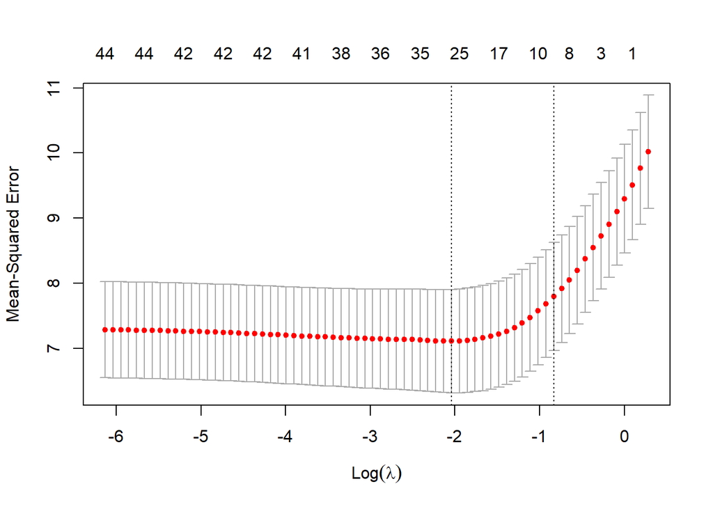

```r
class1 <- student_train$final_grades
class1 <- as.matrix(class1)
class2 <- student_test$final_grades
class3 <- student_cv$final_grades
class3 <- as.numeric(as.character(class3))
class2 <- as.numeric(as.character(class2))
class2 <- as.matrix(class2)
class3 <- as.matrix(class3)
dummy_train_lasso <- as.matrix(dummy_train[,2:57])
dummy_test_lasso <- as.matrix(dummy_test[,2:57])
dummy_cv_lasso <- as.matrix(dummy_cv[,2:57])


cv_student <- cv.glmnet(as.matrix(dummy_train_lasso), class1, family = "gaussian")
lambda_min <- cv_student$lambda.min
plot(cv_student)
```

```r
lasso1 <- glmnet( dummy_train_lasso, dummy_train$final_grades, family='gaussian',lambda = lambda_min)
predict1<- predict(lasso1,dummy_test_lasso)
predict_cv1 <- predict(lasso1,dummy_cv_lasso)
mse_cv_lasso1 <- mse(predict_cv1,class3)/100
mse_lasso1 <- mse(predict1,class2)/100

# L1 penalty with different lambdas (0.3,0.5)

lasso2 <- glmnet( dummy_train_lasso, dummy_train$final_grades, family='gaussian',lambda = 0.3)
predict_cv2 <- predict(lasso2,dummy_cv_lasso)
predict2 <- predict(lasso2,dummy_test_lasso)
mse_cv_lasso2 <- mse(predict_cv2,class3)/100
mse_lasso2 <- mse(predict2,class2)/100

lasso3 <- glmnet( dummy_train_lasso, dummy_train$final_grades, family='gaussian',lambda = 0.5)
predict_cv3 <- predict(lasso3,dummy_cv_lasso)
predict3 <-predict(lasso3,dummy_test_lasso)
mse_cv_lasso3 <- mse(predict_cv3,class3)/100
mse_lasso3 <- mse(predict3,class2)/100

# Table
lambda_012<-c("0.12","0.053","0.100")
lambda_03<-c("0.03","0.054","0.105")
lambda_05<-c("0.5","0.061","0.110")
PRA_TABLE <-rbind(lambda_012,lambda_03,lambda_05)
PRA_TABLE<- as.data.frame(PRA_TABLE)
colnames(PRA_TABLE)<-c("lambda","cv error","test error")
PRA_TABLE
```

[output not shown]

### DECISION TREE APPROACH

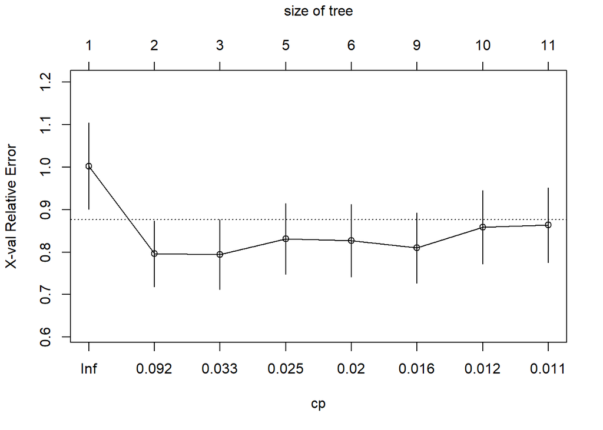

```r
# DECISION TEREE METHOD

test_class <- student_test[,1]
cv_class <- student_cv[,1]

student_test_DT <- student_test[,2:31]
student_cv_DT <- student_cv[,2:31]

final_test <- student_test$final_grades
final_cv <- student_cv$final_grades


reg_tree_1 = rpart(final_grades~.,data = student_train)

plotcp(reg_tree_1)
```

```r
printcp(reg_tree_1)
```

```
##
## Regression tree:
## rpart(formula = final_grades ~ ., data = student_train)
##
## Variables actually used in tree construction:
## [1] absences  failures  Fedu      higher    Medu      school    schoolsup
## [8] sex       studytime
##
## Root node error: 4671.7/467 = 10.004
##
## n= 467
##
##         CP nsplit rel error  xerror     xstd
## 1 0.209601      0   1.00000 1.00270 0.101596
## 2 0.040114      1   0.79040 0.79595 0.077612
## 3 0.027024      2   0.75029 0.79393 0.082268
## 4 0.022262      4   0.69624 0.83154 0.083395
## 5 0.018853      5   0.67397 0.82748 0.085471
## 6 0.012757      8   0.61742 0.80980 0.082737
## 7 0.011086      9   0.60466 0.85832 0.086483
## 8 0.010000     10   0.59357 0.86387 0.088022
```

```r
reg_tree_1$variable.importance
```

```
##   failures     higher       Fedu  schoolsup        age       Medu   absences
## 979.182797 187.399194 180.121555 148.647059 137.913070 108.866713 104.000128
##  studytime     school       Mjob        sex       Walc       Fjob   guardian
## 103.850120  93.540498  78.963234  64.788889  55.566879  34.834358  27.335640
##     reason   freetime traveltime      goout   internet       Dalc       paid
##  24.481287  21.398028  14.031075  10.947382   9.354050   9.213281   3.377499
```

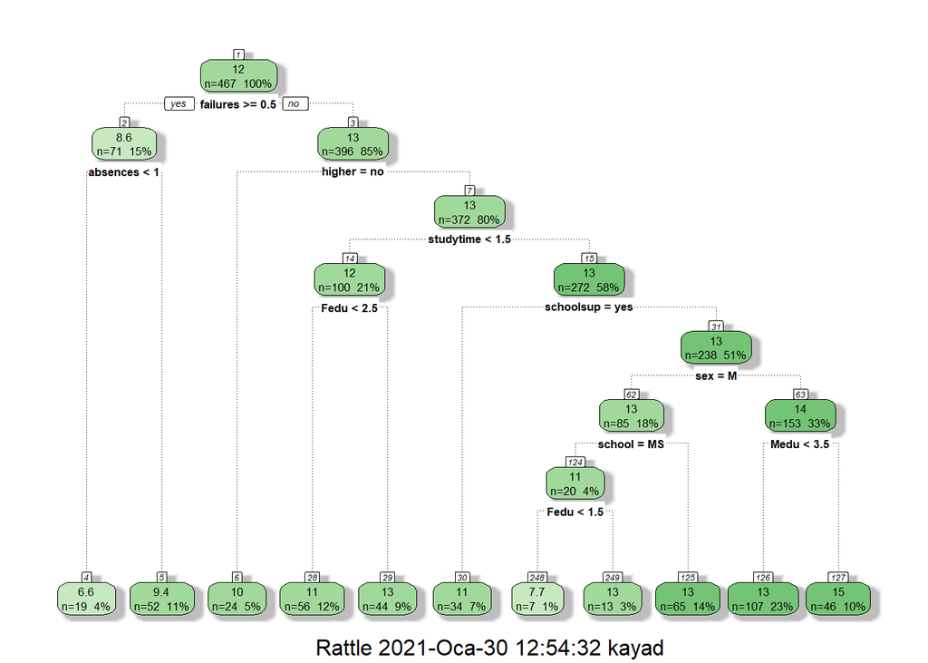

```r
fancyRpartPlot(reg_tree_1)
```

```r
cp = c(0.01,0.03,0.05)
minsplit = c(3,5,10,15)

mse_cv_DT<- c()
mse_DT<-c()
DT_TABLE <-matrix(0,4,12)
test_pred <- matrix(0,130,12)
cv_pred<- matrix(0,52,12)

i=1
for(k in 1:length(minsplit)){
  for(l in 1:length(cp)){
    reg_tree <- rpart(final_grades~.,data = student_train,control = rpart.control(cp = cp[l],minsplit = minsplit[k]))
    reg_tree_cv <- rpart(final_grades~.,data = student_train, control = rpart.control(cp = cp[l],minsplit = minsplit[k]))
    testp <-predict(reg_tree, student_test_DT)
    cv_p  <- predict(reg_tree_cv,student_cv_DT)
    cv_pred[,i] <- as.numeric(as.character(cv_p))
    test_pred[,i] <- as.numeric(as.character(testp))
    test_final <- final_test
    cv_final <- final_cv
    mse_cv_DT[i]<- mse(cv_pred[,i],cv_final)/100
    mse_DT[i] <- mse(test_pred[,i],test_final)/100
    DT_TABLE <- cbind(mse_DT,mse_cv_DT, minsplit,cp)
    i = i+1
  }
}
DT_TABLE
```

```
##          mse_DT  mse_cv_DT minsplit   cp
##  [1,] 0.1291962 0.10321869        3 0.01
##  [2,] 0.1175298 0.08116089        5 0.03
##  [3,] 0.1120089 0.06316426       10 0.05
##  [4,] 0.1175881 0.10578450       15 0.01
##  [5,] 0.1175298 0.08116089        3 0.03
##  [6,] 0.1120089 0.06316426        5 0.05
##  [7,] 0.1194343 0.09406142       10 0.01
##  [8,] 0.1175298 0.08116089       15 0.03
##  [9,] 0.1120089 0.06316426        3 0.05
## [10,] 0.1068437 0.06951899        5 0.01
## [11,] 0.1089917 0.05543136       10 0.03
## [12,] 0.1120089 0.06316426       15 0.05
```

### RANDOM FOREST APPROACH

```r
# RANDOM FOREST MODEL

student_train$final_grades <- as.factor(as.character(student_train$final_grades))
student_test$final_grades  <- as.factor(as.character(student_test$final_grades))


# mtry 10

rforest1<- randomForest(student_train[,2:31],student_train$final_grades,ntree = 500 , nodesize = 5, mtry = 10)
pred_cv_RF1<-predict(rforest1,student_cv[,2:31])
pred_cv_RF1<-as.numeric(as.character(pred_cv_RF1))
pred_RF1<-predict(rforest1,student_test[,2:31])
pred_RF1<-as.numeric(as.character(pred_RF1))
mse_cv_RF1<- mse(pred_cv_RF1,final_cv)/100
mse_RF1 <- mse(pred_RF1,final_test)/100

# mtry 30

rforest2<- randomForest(student_train[,2:31],student_train$final_grades,ntree = 500 , nodesize = 5, mtry = 30)
pred_cv_RF2<-predict(rforest2,student_cv[,2:31])
pred_cv_RF2<-as.numeric(as.character(pred_cv_RF2))
pred_RF2<-predict(rforest2,student_test[,2:31])
pred_RF2<-as.numeric(as.character(pred_RF2))
mse_cv_RF2<- mse(pred_cv_RF1,final_cv)/100
mse_RF2 <- mse(pred_RF1,final_test)/100

# mtry 5

rforest3<- randomForest(student_train[,2:31],student_train$final_grades,ntree = 500 , nodesize = 5, mtry = 5)
pred_cv_RF3<-predict(rforest3,student_cv[,2:31])
pred_cv_RF3<-as.numeric(as.character(pred_cv_RF3))
pred_RF3<-predict(rforest3,student_test[,2:31])
pred_RF3<-as.numeric(as.character(pred_RF3))
mse_cv_RF3<- mse(pred_cv_RF3,final_cv)/100
mse_RF3 <- mse(pred_RF3,final_test)/100

# Table
mtry5<-c("5","0.077","0.117")
mtry10<-c("10","0.074","0.125")
mtry30<-c("30","0.074","0.125")
RF_TABLE <-rbind(mtry5,mtry10,mtry30)
RF_TABLE<- as.data.frame(RF_TABLE)
colnames(RF_TABLE)<-c("mtry","cv error","test error")
RF_TABLE
```

```
##        mtry cv error test error
## mtry5     5    0.077      0.117
## mtry10   10    0.074      0.125
## mtry30   30    0.074      0.125
```

# STOCHASTIC GRADIENT BOOSTING APPROACH

```r
# STOCHASTIC GRADIENT BOOSTING

mse_cv_sgb <- c()
mse_sgb <- c()
pred_test_sgb <-matrix(0,130,27)
pred_cv_sgb<-matrix(0,52,27)
SGB_TABLE <-matrix(0,5,27)
grades <- dummy_train[,1]

shrinkage= c(0.01,0.1,0.5)
ntree=c(100,300,500)
interaction_depth =c(1,2,3)

j=1
for(m in 1:length(ntree)){
  for(n in 1:length(shrinkage)){
    for(p in 1:length(interaction_depth)){

      sgb <- gbm(grades~.,data = dummy_train[,2:57],distribution ="gaussian",n.trees = ntree[m],shrinkage = shrinkage[n], interaction.depth = interaction_depth[p])
      sgb_cv <- gbm(grades~.,data = dummy_train[,2:57],distribution ="gaussian",n.trees = ntree[m],shrinkage = shrinkage[n], interaction.depth = interaction_depth[p])
      pred_cv_sgb [,j] <-predict(sgb_cv,dummy_cv[,2:57])
      pred_test_sgb[,j] <- predict(sgb,dummy_test[,2:57])
      mse_cv_sgb[j] <-mse(pred_cv_sgb[,j],class3)/100
      mse_sgb[j]<- mse(pred_test_sgb[,j],class2)/100
      SGB_TABLE <- cbind(mse_DT,mse_cv_DT, ntree,shrinkage,interaction_depth)
      j=j+1
    }
  }
}

SGB_TABLE
```

```
##          mse_DT  mse_cv_DT ntree shrinkage interaction_depth
##  [1,] 0.1291962 0.10321869   100      0.01                 1
##  [2,] 0.1175298 0.08116089   300      0.10                 2
##  [3,] 0.1120089 0.06316426   500      0.50                 3
##  [4,] 0.1175881 0.10578450   100      0.01                 1
##  [5,] 0.1175298 0.08116089   300      0.10                 2
##  [6,] 0.1120089 0.06316426   500      0.50                 3
##  [7,] 0.1194343 0.09406142   100      0.01                 1
##  [8,] 0.1175298 0.08116089   300      0.10                 2
##  [9,] 0.1120089 0.06316426   500      0.50                 3
## [10,] 0.1068437 0.06951899   100      0.01                 1
## [11,] 0.1089917 0.05543136   300      0.10                 2
## [12,] 0.1120089 0.06316426   500      0.50                 3
```